# ds202_lab4

Jian Kai Lee;jiankailee / Nick Matthews:nickmatthews713

3/20/2020

```r
library(dplyr)
library(readxl)
library(tidyverse)
defense <- read_excel('cyclonesFootball2019.xlsx', sheet='Defensive')
offensive <- read_excel('cyclonesFootball2019.xlsx', sheet='Offensive')
biography <- read_excel('cyclonesFootball2019.xlsx', sheet='Biography')
```

### Part One

```r
# Player and opponent names as factors
defense$Name <- factor(defense$Name)
defense$Opponent_Opponent <- factor(defense$Opponent_Opponent)
# All offensive and defensive statistics made numeric
defClean <- defense %>%
  mutate_at(.funs=function(x) as.numeric(as.character(x)), .vars=c(3:11)) %>%
  mutate_at(.funs=function(x) as.numeric(as.character(x)), .vars=c(3:11))
defe <- defClean

offClean <- offensive %>%
  mutate_at(.funs=function(x) as.numeric(as.character(x)), .vars=c(3:12)) %>%
  mutate_at(.funs=function(x) as.numeric(as.character(x)), .vars=c(3:12))

bioClean <- biography %>%
  separate(Height, into = c("Feet", "Inches")) %>%
  mutate(Height = (as.numeric(Feet)*12 + as.numeric(Inches))) %>%
  select(-c("Feet", "Inches"))



str(defClean)
```

```
## Classes 'tbl_df', 'tbl' and 'data.frame':    502 obs. of  11 variables:
##  $ Name             : Factor w/ 43 levels "Akers, Landen",..: 40 40 40 40 40 40 40 40 40 40 ...
##  $ Opponent_Opponent: Factor w/ 13 levels "Baylor","Iowa",..: 12 2 11 1 8 13 10 7 6 9 ...
##  $ Tackles_Solo     : num  4 4 3 4 3 1 7 3 6 5 ...
##  $ Tackles_ASST     : num  4 7 5 2 2 1 1 2 1 5 ...
##  $ Tackles_TFL      : num  0 0 0 0 1 0 0 0 1 1 ...
##  $ Tackles_Sack     : num  0 0 0 0 0 0 0 0 0 1 ...
##  $ Turnover_FF      : num  0 0 0 0 0 0 0 0 0 0 ...
##  $ Turnover_FR      : num  0 0 0 0 0 0 0 0 0 0 ...
##  $ Turnover_INT     : num  0 0 1 0 0 0 0 0 1 0 ...
##  $ Pass_QBH         : num  1 0 0 0 0 0 0 0 1 0 ...
##  $ Pass_PB          : num  1 2 0 0 0 1 0 0 0 0 ...
```

```r
str(offClean)
```

```
## Classes 'tbl_df', 'tbl' and 'data.frame':    195 obs. of  12 variables:
##  $ Name             : chr  "Akers, Landen" "Akers, Landen" "Akers, Landen" "Akers, Landen" ...
##  $ Opponent_Opponent: chr  "UNI" "Iowa" "ULM" "Baylor" ...
##  $ Rushing_ATT      : num  0 0 1 0 0 0 0 0 0 0 ...
##  $ Rushing_YDS      : num  0 0 8 0 0 0 0 0 0 0 ...
##  $ Rushing_TD       : num  0 0 0 0 0 0 0 0 0 0 ...
##  $ Receiving_REC    : num  1 0 0 0 1 0 0 4 0 1 ...
##  $ Receiving_YDS    : num  21 0 0 0 32 0 0 39 0 7 ...
##  $ Receiving_TD     : num  0 0 0 0 0 0 0 0 0 0 ...
##  $ Passing_CMP-ATT  : num  NA NA NA NA NA NA NA NA NA NA ...
##  $ Passing_YDS      : num  NA NA NA NA NA NA NA NA NA NA ...
##  $ Passing_TD       : num  NA NA NA NA NA NA NA NA NA NA ...
##  $ Passing_INT      : num  NA NA NA NA NA NA NA NA NA NA ...
```

```r
str(bioClean)
```

```
## Classes 'tbl_df', 'tbl' and 'data.frame':    105 obs. of  7 variables:
##  $ Name      : chr  "Akers, Landen" "Allen, Chase" "Anderson, Ezeriah" "Assalley, Connor" ...
##  $ Position  : chr  "Wide Receiver" "Tight End" "Wide Receiver" "Placekicker" ...
##  $ Weight    : chr  "188" "245" "204" "195" ...
##  $ Class     : chr  "Redshirt Senior" "Redshirt Senior" "Redshirt Freshman" "Redshirt Senior" ...
##  $ Hometown  : chr  "Cedar Rapids, Iowa" "Nixa, Mo." "Seffner, Fla." "Naperville, Ill." ...
##  $ Highschool: chr  "Washington" "Nixa" "Armwood" "Central" ...
##  $ Height    : num  72 79 77 72 72 75 74 74 72 78 ...
```

### Part Two

#### 1) Reformatting defClean

```r
defClean <- defClean %>%
  pivot_longer(Tackles_Solo:Pass_PB, names_to = "Statistic", values_to = "values")
```

#### 2) Histogram of defense

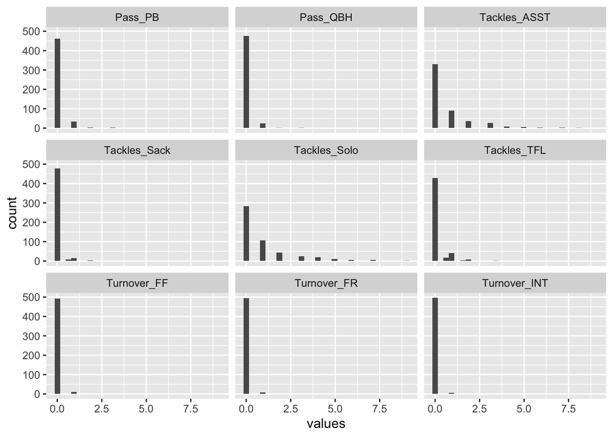

```r
defClean %>%
  ggplot(aes(x=values)) + geom_histogram() + facet_wrap(~Statistic)
```

**Description:** The rare defensive statistics will be the ones happening around 0 times per game. So, intuitively, these statistics are Turnover_INT, Turnover_FR, Turnover_FF, and Tackles_Sack.

#### 3) Scatterplot of solo tackles against WV and KS

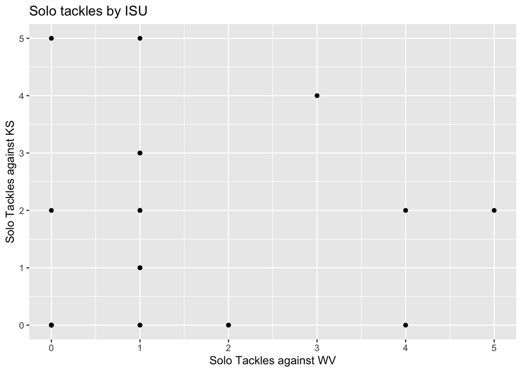

```r
KansasVirginiaST <- defClean %>%
  filter(Opponent_Opponent == "Kansas State" | Opponent_Opponent == "West Virginia") %>%
  filter(Statistic == "Tackles_Solo") %>%
  pivot_wider(names_from = "Opponent_Opponent", values_from = "values") %>%
  na.omit()

#Rename columns so that its easier to read
colnames(KansasVirginiaST)[colnames(KansasVirginiaST) == "West Virginia"] <- "West.Virginia"
colnames(KansasVirginiaST)[colnames(KansasVirginiaST) == "Kansas State"] <- "Kansas.State"

KansasVirginiaST %>%
  ggplot(aes(x=West.Virginia, y=Kansas.State)) + geom_point() + xlab("Solo Tackles against WV") + ylab("Solo Tackles against KS") + ggtitle("Solo tackles by ISU")
```

**Description:** It’s a little hard to tell, but looking closely, Iowa state players appear to have more solo tackles against Kansas state than West Virginia

#### 4) Separating Hometown into two columns

```r
bioClean <- bioClean %>%
  separate(Hometown, c("City", "State"), sep=",")

playersByState <- bioClean %>%
  group_by(State) %>%
  summarise(Number_of_players = n())

playersByState
```

```
## # A tibble: 19 x 2
##    State        Number_of_players
##    <chr>                    <int>
##  1 " Ariz."                     4
##  2 " Ark."                      1
##  3 " Australia"                 1
##  4 " Calif."                    3
##  5 " Fla."                     10
##  6 " Ga."                       4
##  7 " Ill."                      5
##  8 " Iowa"                     35
##  9 " Kan."                      3
## 10 " Mich."                     4
## 11 " Minn."                     4
## 12 " Miss."                     1
## 13 " Mo."                       6
## 14 " Ohio"                      7
## 15 " Okla."                     2
## 16 " Pa."                       1
## 17 " S.D."                      2
## 18 " Texas"                     6
## 19 " Wis."                      6
```

### Part Three

#### 1) Joining offensive data and biography data

```r
# Subset of the data bioClean dataframe filled with only information we need for the next few problems
home_and_weight <- select(bioClean, c("Name", "City", "State", "Weight"))

# Joined offensive and above subset using left_join so as to keep all offensive players stats, even if they don't have a hometown or weight recorded
offBio <- offClean %>%
  left_join(home_and_weight, by = "Name")
```

#### 2) Is there a relationship between weight and recieving yards?

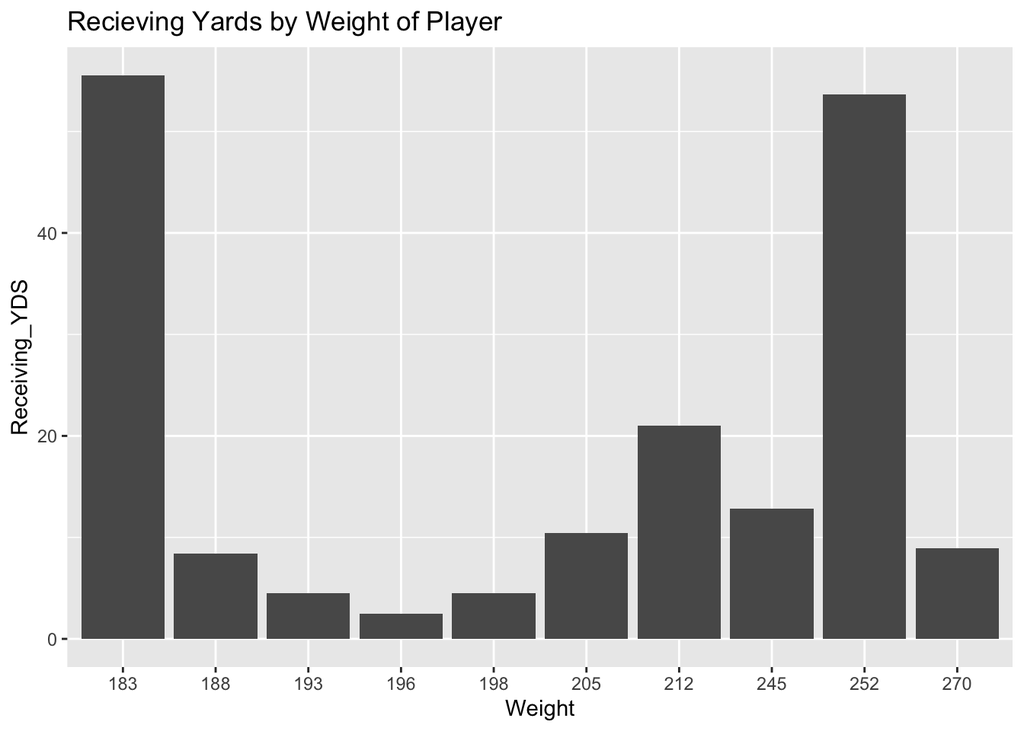

```r
# summarise the mean receiving yards for each weight, Dropping any rows that dont have a recorded weight or receiving yards
offBio %>%
  drop_na(Weight, Receiving_YDS) %>%
  group_by(Weight) %>%
  summarise(Receiving_YDS = mean(Receiving_YDS)) %>%
  ggplot(aes(x=Weight, y=Receiving_YDS)) + geom_bar(stat = "identity") +
  ggtitle("Recieving Yards by Weight of Player")
```

### 3) Preformance of Brock Purdy vs the entire ISU team

*For this problem, we think the best way to look at how brock purdy’s preformance is related to the entire team preformance, is by looking at his passing yards. Brock Purdy usually has one job every play and that is to pass the ball or run it if he can. The further he passes/runs the ball successfully. the better hos preformance. We’ll look at these numbers in relation with other players*

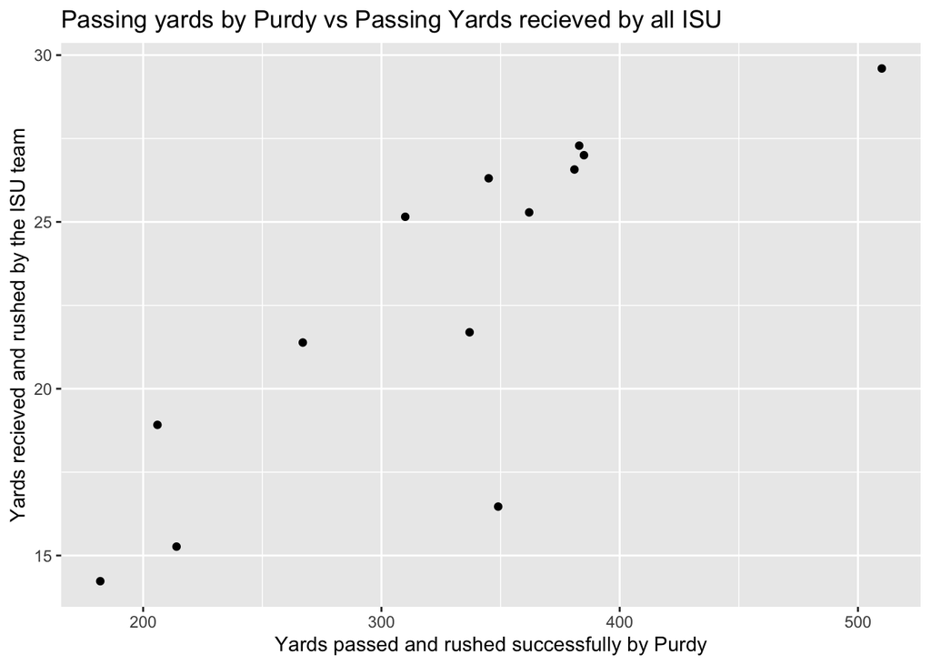

```r
Purdy <- offClean %>%
  filter(Name == "Purdy, Brock") %>%
  mutate(total_yards = (Rushing_YDS + Passing_YDS))

allISU <- offClean %>%
  group_by(Opponent_Opponent) %>%
  drop_na(Receiving_YDS) %>%
  summarise(total_recieved = mean(Receiving_YDS))

purdy_and_all <- full_join(Purdy, allISU, by="Opponent_Opponent")

purdy_and_all %>%
  ggplot(aes(x=total_yards, y=total_recieved)) + geom_point() +
  ggtitle("Passing yards by Purdy vs Passing Yards recieved by all ISU") +
  xlab("Yards passed and rushed successfully by Purdy") +
  ylab("Yards recieved and rushed by the ISU team")
```

**Description:** It appears that at each game, as Purdy was more successful with his passing and rushing yards, so was the ISU offense with obtaining more yards

### 4) Exploring More

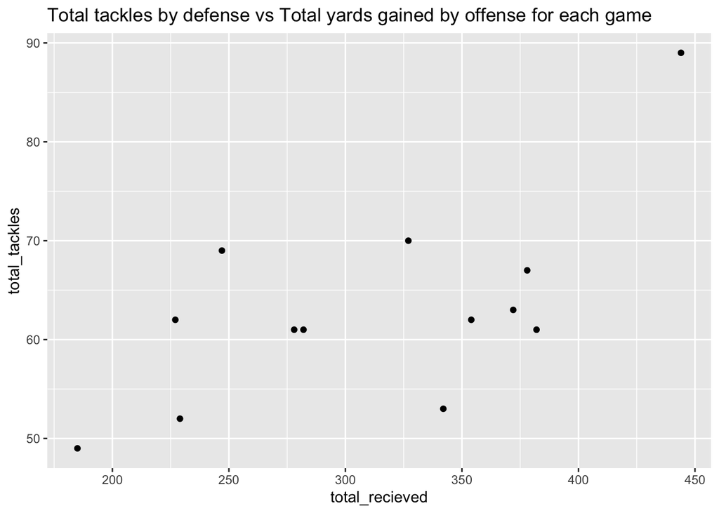

```r
defeTackles <- defe %>%
  group_by(Opponent_Opponent) %>%
  drop_na(Tackles_Solo, Tackles_ASST) %>%
  summarise(total_tackles = sum(Tackles_Solo + Tackles_ASST))

offYards <- offClean %>%
  drop_na(Receiving_YDS) %>%
  group_by(Opponent_Opponent) %>%
  summarise(total_recieved = sum(Receiving_YDS))

defOff <- full_join(defeTackles, offYards, by="Opponent_Opponent")

defOff %>%
  ggplot(aes(x=total_recieved, total_tackles)) + geom_point() +
  ggtitle("Total tackles by defense vs Total yards gained by offense for each game")
```

**Description:** With not a lot of games, It’s hard to see a relationship here, but to me, it looks slightly positive. Offense and Defense play at different times, so its hard to find a solid relationship between their numbers. Though, its completely possible that they effect eachother.